# Maggiore/Lugano

## Utility of the objects found

The utility type is based on the utilization of the object prior to it being discarded or object description if the original use is undetermined. Identified objects are classified into one of 260 predefined categories. The categories are grouped according to utilization or item description.

- **wastewater**: items released from water treatment plants includes items likely toilet flushed
- **micro plastics (< 5mm)**: fragmented plastics and pre-production plastic resins
- **infrastructure**: items related to construction and maintenance of buildings, roads and water/power supplies
- **food and drink**: all materials related to consuming food and drink
- **agriculture**: primarily industrial sheeting i.e., mulch and row covers, greenhouses, soil fumigation, bale wraps. Includes hard plastics for agricultural fencing, flowerpots etc.
- **tobacco**: primarily cigarette filters, includes all smoking related material
- **recreation**: objects related to sports and leisure i.e., fishing, hunting, hiking etc.
- **packaging non food and drink**: packaging material not identified as food, drink nor tobacco related
- **plastic fragments**: plastic pieces of undetermined origin or use
- **personal items**: accessories, hygiene and clothing related

See the annex for the complete list of objects identified, includes descriptions and group classification. The section Code groups describes each code group in detail and provides a comprehensive list of all objects in a group.

**Below:** Bielersee utility of objects found % of total by municipality. Fragmented objects with no clear identification remain classified by size:

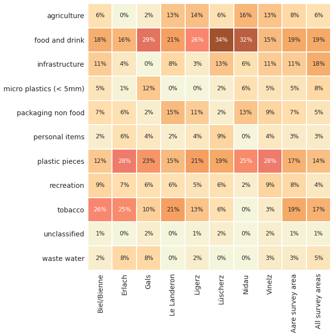

**Below:** Bielersee utility of objects found median p/100m. Fragmented objects with no clear identification remain classified by size:

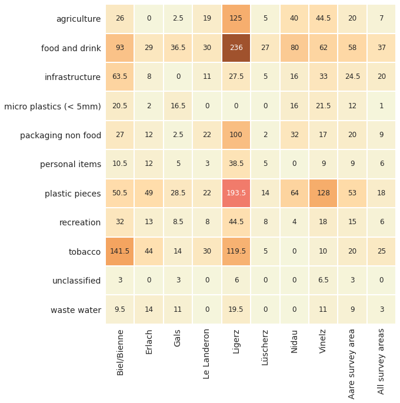

## Annex

### Fragmented foams and plastics by size

The table below contains the “Gfoam” and “Gfrags” components grouped for analysis. Objects labeled expanded foams are grouped as Gfoam and includes all expanded polystyrene foamed plastics > 0.5 cm. Plastic pieces and objects made of combined plastic and foamed plastic materials > 0.5 cm. are grouped for analysis as Gfrags.

**Below:** Bielersee fragmented foams and plastics by size group.

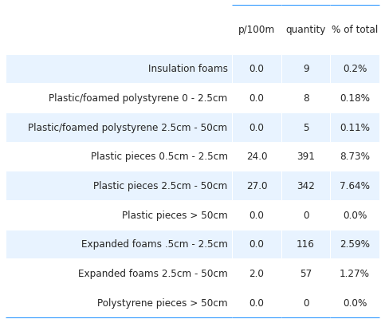

### Organizations

1. Hammerdirt
2. Precious Plastic Leman

**The survey locations**

| location | latitude | longitude | city |
| --- | --- | --- | --- |
| mullermatte | 47.133339 | 7.227907 | Biel/Bienne |
| bielersee_vinelz_fankhausers | 47.038398 | 7.108311 | Vinelz |
| erlach-camping-strand | 47.047159 | 7.097854 | Erlach |
| luscherz-plage | 47.047955 | 7.151242 | Lüscherz |
| strandboden-biel | 47.132510 | 7.233142 | Biel/Bienne |
| nidau-strand | 47.127196 | 7.232613 | Nidau |
| camp-des-peches | 47.052812 | 7.074053 | Le Landeron |
| ligerz-strand | 47.083979 | 7.135894 | Ligerz |
| gals-reserve | 47.046272 | 7.085007 | Gals |
| luscherz-two | 47.047519 | 7.152829 | Lüscherz |

### Inventory of items

| code | item | groupname | quantity | % of total | fail rate |
| --- | --- | --- | --- | --- | --- |
| Gfrags | Fragmented plastics | plastic pieces | 746 | 16.66 | 97 |
| G27 | Cigarette filters | tobacco | 744 | 16.62 | 78 |
| G30 | Food wrappers; candy, snacks | food and drink | 325 | 7.26 | 86 |
| G67 | Industrial sheeting | agriculture | 300 | 6.70 | 89 |
| G200 | Glass drink bottles, pieces | food and drink | 176 | 3.93 | 68 |
| G941 | Packaging films nonfood or unknown | packaging non food | 173 | 3.86 | 63 |
| Gfoam | Expanded polystyrene | infrastructure | 173 | 3.86 | 63 |
| G940 | Foamed EVA for crafts and sports | recreation | 92 | 2.05 | 31 |
| G25 | Tobacco; plastic packaging, containers | tobacco | 92 | 2.05 | 73 |
| G89 | Plastic construction waste | infrastructure | 89 | 1.99 | 71 |
| G117 | Expanded foams < 5mm | micro plastics (< 5mm) | 77 | 1.72 | 34 |
| G904 | Plastic fireworks | recreation | 76 | 1.70 | 68 |
| G74 | Insulation foams | infrastructure | 72 | 1.61 | 50 |
| G112 | Industrial pellets (nurdles) | micro plastics (< 5mm) | 71 | 1.59 | 60 |
| G95 | Cotton bud/swab sticks | waste water | 68 | 1.52 | 50 |
| G213 | Paraffin wax | recreation | 65 | 1.45 | 26 |
| G177 | Foil wrappers, aluminum foil | food and drink | 61 | 1.36 | 60 |
| G156 | Paper fragments | packaging non food | 49 | 1.09 | 31 |
| G106 | Plastic fragments angular <5mm | micro plastics (< 5mm) | 46 | 1.03 | 47 |
| G73 | Foamed items & pieces (non packaging/insulatio... | recreation | 40 | 0.89 | 31 |
| G23 | Lids unidentified | packaging non food | 36 | 0.80 | 42 |
| G31 | Lollypop sticks | food and drink | 35 | 0.78 | 39 |
| G24 | Plastic lid rings | food and drink | 35 | 0.78 | 44 |
| G33 | Lids for togo drinks plastic | food and drink | 32 | 0.71 | 42 |
| G178 | Metal bottle caps and lids | food and drink | 31 | 0.69 | 47 |
| G35 | Straws and stirrers | food and drink | 31 | 0.69 | 44 |
| G211 | Swabs, bandaging, medical | personal items | 29 | 0.65 | 50 |
| G50 | String < 1cm | recreation | 25 | 0.56 | 34 |
| G922 | Labels, bar codes | packaging non food | 24 | 0.54 | 31 |
| G10 | Food containers single use foamed or plastic | food and drink | 24 | 0.54 | 42 |

[output cut: 106 more lines]